```python
%matplotlib inline
```

# Predicting credit card default with Taiwanese consumer data

Jacob Gull, Joel Casillas, Hugo Hernandez

October 24, 2018

## Introduction

Credit risk assessment is important for creditors to be able make lending choices that benefit both the consumer and creditor. In the United States, credit scores from major credit reporting agencies are typically used to make lending choices, but machine learning can be used to make predictions for loan repayment as an alternate assessment of a borrower. This might be beneficial for making lending decisions for populations with low traditional credit scores or limited credit history.

The data we will be using is the default of credit card clients Data Set from the UC Irvine data repository, found here:

(https://archive.ics.uci.edu/ml/datasets/default+of+credit+card+clients)

This is data collected of customers default payments in Taiwan. It contains 24 attributes and 30,000 instances. The data was collected from April 2005-September 2005. We are going to be exploring the data and looking for any interesting datapoints in the data set.

```python
import numpy as np
import pandas as pd
import seaborn as sns
import warnings
import matplotlib.pyplot as plt; plt.rcdefaults()
import matplotlib.pyplot as plt
warnings.filterwarnings("ignore")
from sklearn.svm import SVC
from sklearn.model_selection import train_test_split
from sklearn.ensemble import RandomForestClassifier, VotingClassifier
from sklearn.metrics import confusion_matrix
from sklearn.ensemble import RandomForestClassifier
from sklearn import datasets
from sklearn.feature_selection import RFE
from sklearn.linear_model import LogisticRegression
from sklearn.ensemble import GradientBoostingClassifier
from sklearn.ensemble import AdaBoostClassifier
import matplotlib.gridspec as gridspec
import itertools
from sklearn.metrics import mean_squared_error
from sklearn.model_selection import train_test_split
from sklearn.metrics import roc_curve
from sklearn import preprocessing
from sklearn.metrics import accuracy_score
from sklearn.ensemble import ExtraTreesClassifier
from sklearn.svm import LinearSVC
from sklearn.neural_network import MLPClassifier
import warnings
warnings.filterwarnings("ignore", category=DeprecationWarning)
from sklearn.ensemble import BaggingClassifier
from sklearn.metrics import roc_curve, auc, roc_auc_score
from sklearn.tree import DecisionTreeClassifier
```

Reading in the data

```python
Hugo = "/Users/Hugo/Downloads/default_cc_train.csv"
Joel = "/Users/joelcasillas/Downloads/default_cc_train.csv"
Jacob = '/Users/jacobgull/Downloads/default_cc_train.csv'
df=pd.read_csv(Hugo)
```

## Data Exploration

Here we're going to be exploring the data and looking for anything interesting. We will be looking for trends in the data as well as outliers.

```python
df.head()
```

|  | ID | LIMIT_BAL | SEX | EDUCATION | MARRIAGE | AGE | PAY_0 | PAY_2 | PAY_3 | PAY_4 | ... | BILL_AMT4 | BILL_AMT5 | BILL_AMT6 | PAY_AMT1 | PAY_AMT2 | PAY_AMT3 | PAY_AMT4 | PAY_AMT5 | PAY_AMT6 | default.payment.next.month |
| --- | --- | --- | --- | --- | --- | --- | --- | --- | --- | --- | --- | --- | --- | --- | --- | --- | --- | --- | --- | --- | --- |
| 0 | 8811 | 390000 | 2 | 1 | 1 | 64 | 1 | -2 | -2 | -2 | ... | 0 | 0 | 8668 | 0 | 0 | 0 | 0 | 8668 | 4490 | 1 |
| 1 | 23496 | 60000 | 2 | 2 | 2 | 31 | 0 | 0 | 0 | 2 | ... | 42057 | 26877 | 26493 | 4100 | 4073 | 0 | 1600 | 0 | 1100 | 1 |
| 2 | 1164 | 210000 | 2 | 2 | 1 | 39 | 0 | 0 | 0 | 0 | ... | 19850 | 15530 | 13021 | 14000 | 3007 | 5000 | 1000 | 13021 | 22171 | 0 |
| 3 | 19421 | 500000 | 2 | 1 | 1 | 35 | -2 | -1 | 0 | -1 | ... | 7896 | 8970 | 215305 | 36277 | 6112 | 10014 | 9018 | 215518 | 20018 | 0 |
| 4 | 16890 | 150000 | 1 | 1 | 2 | 37 | 2 | 2 | 2 | 2 | ... | 38687 | 37765 | 40352 | 1600 | 0 | 3300 | 0 | 3200 | 1700 | 1 |

5 rows × 25 columns

```python
df.count()/len(df)
```

```
ID                            1.0
LIMIT_BAL                     1.0
SEX                           1.0
EDUCATION                     1.0
MARRIAGE                      1.0
AGE                           1.0
PAY_0                         1.0
PAY_2                         1.0
PAY_3                         1.0
PAY_4                         1.0
PAY_5                         1.0
PAY_6                         1.0
BILL_AMT1                     1.0
BILL_AMT2                     1.0
BILL_AMT3                     1.0
BILL_AMT4                     1.0
BILL_AMT5                     1.0
BILL_AMT6                     1.0
PAY_AMT1                      1.0
PAY_AMT2                      1.0
PAY_AMT3                      1.0
PAY_AMT4                      1.0
PAY_AMT5                      1.0
PAY_AMT6                      1.0
default.payment.next.month    1.0
dtype: float64
```

This tells us that the dataset does not contain any NaN values.

```python
df["default.payment.next.month"].value_counts()/len(df)
```

```
0    0.77944
1    0.22056
Name: default.payment.next.month, dtype: float64
```

We can see that only about 22% of people defaulted on the bill.

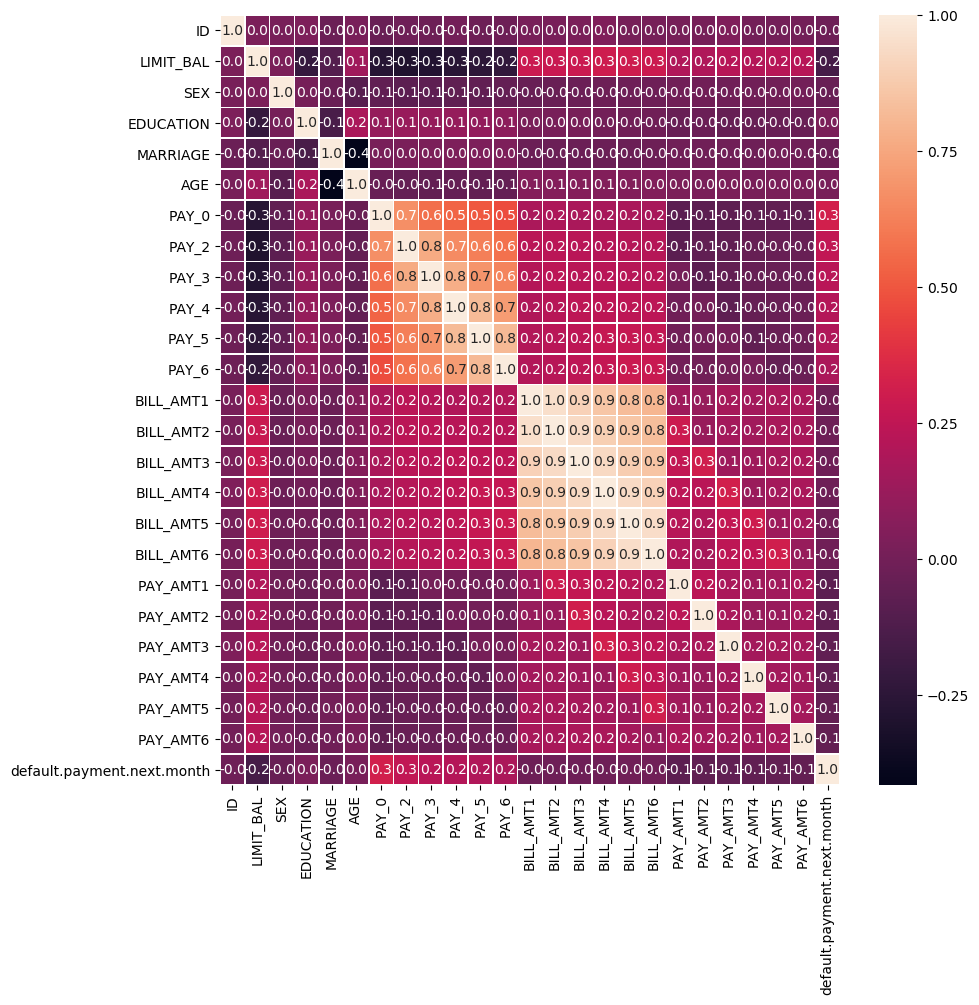

```python
f,ax = plt.subplots(figsize=(10, 10))
sns.heatmap(df.corr(), annot=True, linewidths=.5, fmt= '.1f',ax=ax);
plt.show()
```

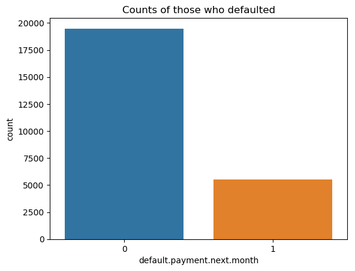

```python
sns.countplot(x="default.payment.next.month", data=df)
plt.title("Counts of those who defaulted");
plt.show()
```

This also shows us that the majority of people didn't default on there credit card payment.

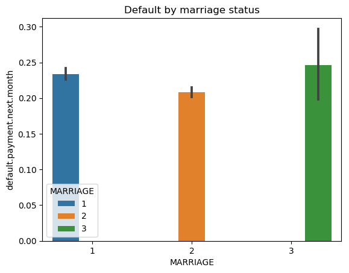

```python
df.loc[df['MARRIAGE'] == 0, 'MARRIAGE'] = 3
sns.barplot(x="MARRIAGE", y="default.payment.next.month", hue="MARRIAGE", data=df)
plt.title("Default by marriage status");
plt.show()
```

Here we wanted to see the likelihood of defaulting in regards to marriage status. The 1 means that the person is married, 2 means that they're single, and 3 means other. We assume 3 contains people who are divorced, or widowed.

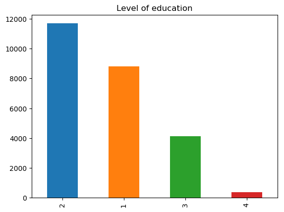

```python
df.loc[df['EDUCATION'] == 6, 'EDUCATION'] = 4
df.loc[df['EDUCATION'] == 5, 'EDUCATION'] = 4
df.loc[df['EDUCATION'] == 0, 'EDUCATION'] = 4
labels = ('random set 1', 'random set 2')
df["EDUCATION"].value_counts().plot(kind="bar")
plt.title("Level of education");
plt.show()
```

X-axis = (1 = graduate school; 2 = university; 3 = high school; 4 = others).

y-axis = number of people.

This graph represents levels of education and the number of applicants with credit. Clearly we can see within the data set there is more data entries of university students with credit cards than the other groups.

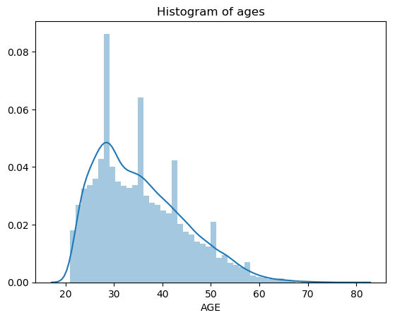

```python
sns.distplot(df['AGE'].dropna())
plt.title("Histogram of ages");
plt.show()
```

This plot shows that the people that are in debt are roughly between the ages of 20-63. This makes sense since people under 20 aren't very independent, therefore they wouldn't have much of an income coming in. It also makes sense that the plot drops down around the age of 60 because most of those ideally would have there debts payed and retired.

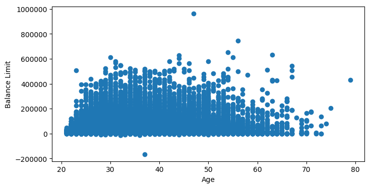

```python
fig, ax = plt.subplots(figsize=(8,4))
ax.scatter(df['AGE'],df['BILL_AMT1'])
ax.set_xlabel('Age')
ax.set_ylabel('Balance Limit')
plt.show();
```

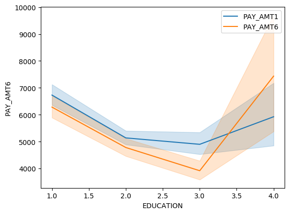

```python
objects = ('1', '2', '3', '4')
y_pos = np.arange(len(objects))
temp=pd.melt(df,"PAY_0",var_name="Education")
sns.lineplot(x="EDUCATION",y="PAY_AMT1",data=df,label="PAY_AMT1")
sns.lineplot(x="EDUCATION",y="PAY_AMT6",data=df,label="PAY_AMT6");
plt.show()
```

I wanted to see how much the difference between the first pay amount compared to the last month of the pay amount with regards to education. The points to be looking at on this plot are 1,2,3 and 4, and here are there signifigance. Education (1 = graduate school; 2 = university; 3 = high school; 4 = others). We assume other is those who did not complete high school or never went to school at all.

## Preprocessing

The data set was already pretty clean when we got it, so there wasn't much cleaning to do. No NaN values, empty values or spaces were found. We did however notice that the data set contained values 0 in the marriage column, so we decided to group the 0's and group them into 3's which stands for others in the data set. We also decided to rename the default feature because the original name was too long and complex.

We also created two new features, BILL_AMT_MEAN and PAY_AMT_MEAN which is the mean of the pay amount and bill amount for each instance.

```python
df.loc[df['MARRIAGE'] == 0, 'MARRIAGE'] = 3
df.rename(columns={'default.payment.next.month': 'Default'}, inplace=True)
col = df.loc[: , "BILL_AMT1":"BILL_AMT6"]
df['BILL_AMT_MEAN'] = col.mean(axis=1)
col2 = df.loc[: , "PAY_AMT1":"PAY_AMT6"]
df['PAY_AMT_MEAN'] = col2.mean(axis=1)
df.loc[df['EDUCATION'] == 6, 'EDUCATION'] = 4
df.loc[df['EDUCATION'] == 5, 'EDUCATION'] = 4
df.loc[df['EDUCATION'] == 0, 'EDUCATION'] = 4
```

```python
# normalizing data
scaledAmounts = ['LIMIT_BAL','BILL_AMT1','BILL_AMT2','BILL_AMT3','BILL_AMT4','BILL_AMT5','BILL_AMT6','PAY_AMT1','PAY_AMT2','PAY_AMT3','PAY_AMT4','PAY_AMT5','PAY_AMT6']

x = df[scaledAmounts].values #returns a numpy array
min_max_scaler = preprocessing.MinMaxScaler()
x_scaled = min_max_scaler.fit_transform(x)
df_scale = pd.DataFrame(x_scaled)
df[scaledAmounts] = df_scale
```

```python
# This rocCurve plot will help us later with comparing classifiers
def rocCurve(aClf,X_test,y_test,modelName):
    roc_auc = roc_auc_score(y_test, aClf.predict(X_test))
    fpr, tpr, thresholds = roc_curve(y_test, aClf.predict_proba(X_test)[:,1])
    plt.figure()
    plt.plot(fpr, tpr, label='Model({modelName}) (area = %0.2f)' % roc_auc)
    plt.plot([0, 1], [0, 1],'r--')
    plt.xlim([0.0, 1.0])
    plt.ylim([0.0, 1.05])
    plt.xlabel('False Positive Rate')
    plt.ylabel('True Positive Rate')
    plt.title('Receiver operating characteristic')
    plt.legend(loc="lower right")
    plt.savefig('Log_ROC')
    plt.show()
```

We also decided to create this ROC Curve function that plots the ROC of a given model.

## Base Classifier: Random Forest

```python
X = df[["PAY_AMT1","LIMIT_BAL","EDUCATION","PAY_0","PAY_2","PAY_3","PAY_4","PAY_6"]]
y = df['Default']
```

```python
X_train, X_test, y_train, y_test = train_test_split(X, y, test_size=.30)
```

We will be also trying out Random Forest and seeing how it predicts without hypertuning the parameters.

```python
clf = RandomForestClassifier( random_state=20)
```

```python
clf.fit(X_train, y_train)
```

```
RandomForestClassifier(bootstrap=True, class_weight=None, criterion='gini',
            max_depth=None, max_features='auto', max_leaf_nodes=None,
            min_impurity_decrease=0.0, min_impurity_split=None,
            min_samples_leaf=1, min_samples_split=2,
            min_weight_fraction_leaf=0.0, n_estimators=10, n_jobs=None,
            oob_score=False, random_state=20, verbose=0, warm_start=False)
```

```python
y_pred = clf.predict(X_test)
lr_scores = clf.score(X_test, y_test)
```

```python
confusion_matrix = confusion_matrix(y_test, y_pred)
print(confusion_matrix)
```

```
[[5304  578]
 [1060  558]]
```

```python
print('The Accuracy of our classifier using Random Forest Classifier is: {:.2f}'.format(clf.score(X_test, y_test)))
```

```
The Accuracy of our classifier using Random Forest Classifier is: 0.78
```

## Recursive Feature Elimination

Based off the performance of our base classifier above, we decided to use recursive feature elimination to get the most important features from the data set to predict on. We created another Random Forest model, but this time using the top 5 most important features from Recursive Feature Elimination. To our surprise, the accuracy of the model was still pretty much the same. We tried using a different number of features and we noticed the more features we used, the better the model performed. Performance suffered when the number of features was reduced.

```python
from sklearn.feature_selection import RFE
# Making a RFE model and select 5 attributes
rfe = RFE(clf, 5)
rfe = rfe.fit(X_train, y_train)
# summarizing the selection of the attributes
print(rfe.support_)
print(rfe.ranking_)
```

```
[ True  True False  True  True False False  True]
[1 1 3 1 1 4 2 1]
```

## Feature Importance

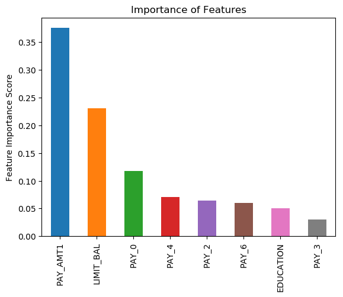

```python
predictors=list(X_train)
feat_imp = pd.Series(clf.feature_importances_, predictors).sort_values(ascending=False)
feat_imp.plot(kind='bar', title='Importance of Features')
plt.ylabel('Feature Importance Score');
plt.show()
```

Here we also have the feature importance of the model and it gives us similar results to the Recursive Feature Elimination from above.

```python
y_pred2 = rfe.predict(X_test)
lr_scores2 = rfe.score(X_test, y_test)
```

```python
print('The Accuracy of our classifier using Recursive Feature Elimination is: {:.2f}'.format(rfe.score(X_test, y_test)))
```

```
The Accuracy of our classifier using Recursive Feature Elimination is: 0.78
```

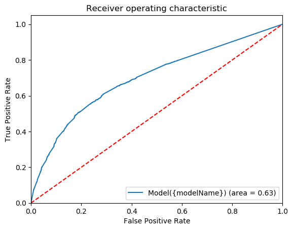

```python
rocCurve(rfe,X_test,y_test,"Recursive Feature Elimination")
```

The ROC curve measures how well the parameters can distinguish between whether someone would default or not.

## Support Vector Machine

```python
svm_clf = SVC(C=1.0, cache_size=200, class_weight=None, coef0=0.0,
  decision_function_shape='ovr', degree=3, gamma='auto', kernel='rbf',
  max_iter=-1, probability=True, random_state=0, shrinking=True,
  tol=0.001, verbose=False)
svm_clf.fit(X_train, y_train)
```

```
SVC(C=1.0, cache_size=200, class_weight=None, coef0=0.0,
  decision_function_shape='ovr', degree=3, gamma='auto', kernel='rbf',
  max_iter=-1, probability=True, random_state=0, shrinking=True, tol=0.001,
  verbose=False)
```

```python
print('The Accuracy of our classifier using Recursive Feature Elimination is: {:.2f}'.format(svm_clf.score(X_test, y_test)))
```

```
The Accuracy of our classifier using Recursive Feature Elimination is: 0.83
```

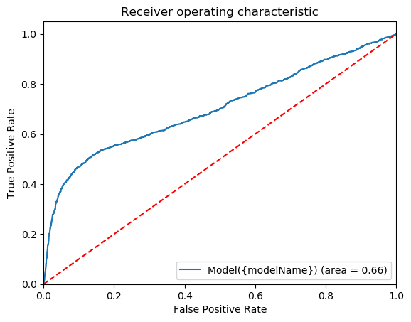

```python
rocCurve(svm_clf,X_test,y_test,"Support Vector Machine")
```

As a result, we can see with an ROC curve that the model is poor in accuracy. However, it is better than other classifiers in our research such as the recursive_feature_elimination.

# Use of and experimentation with dimensionality reduction

## Ensemble Methods for Gradient Boosting & Voting Classifier

```python
def gradBoost(X_train,y_train,X_test,y_test,learning_rates):
    # learning_rates = np.arange(0.74,.76,0.001)
    for learning_rate in learning_rates:
        boost = GradientBoostingClassifier(n_estimators=20, learning_rate = learning_rate, max_features=2, max_depth = 2, random_state = 0)
        boost.fit(X_train, y_train)
        print("Learning rate: ", learning_rate)
        print("Accuracy score for training data : {0:.3f}".format(boost.score(X_train, y_train)))
        print("Accuracy score for TEST set: {0:.3f}".format(boost.score(X_test, y_test)))
```

Here we created a gradBoost method that will help us tune hyperparameters of our Gradient Boosting Classifier while also fitting it and prinitng it's score based on the different learning rates. This will help us see what learning rate corresponds to the best model.

```python
def votingClass(X_train,y_train,X_test,y_test):
    extra_trees_clf = ExtraTreesClassifier(random_state=42)
    mlp_clf = MLPClassifier(random_state=42)
    log_clf = LogisticRegression(random_state=42)
    rnd_clf = RandomForestClassifier(random_state=42)
    svm_clf = SVC(random_state=42)
    voting_clf = VotingClassifier(
        estimators=[('xt', extra_trees_clf), ('mlp', mlp_clf), ('lr', log_clf), ('rf', rnd_clf), ('svc', svm_clf)],
        voting='hard')
    voting_clf.fit(X_train, y_train)
    from sklearn.metrics import accuracy_score
    for clf in (extra_trees_clf, log_clf, rnd_clf, svm_clf, voting_clf):
        clf.fit(X_train, y_train)
        y_pred = clf.predict(X_test)
        print(clf.__class__.__name__, accuracy_score(y_test, y_pred))
```

We also made a Voting Classifier similat to the GradBoost one above to help tune parameters and get a better model.

## Principal Component Analysis

Pricincpal Compnent analysis will be used to emphasize variation and see patterns that are promient in the dataset.

```python
from sklearn.decomposition import PCA, IncrementalPCA
model = PCA(n_components=2)
model = model.fit(X)
print(model.components_)
```

```
[[-5.58264883e-04 -1.92189206e-02  5.26130603e-02  3.81192124e-01
   4.73687788e-01  4.87117738e-01  4.65132004e-01  4.16585116e-01]
 [ 3.80992949e-03  1.05123649e-02 -8.42897962e-02 -6.66286933e-01
  -3.52622301e-01  7.13253960e-02  3.55777288e-01  5.41132746e-01]]
```

```python
print(model.explained_variance_ratio_)
```

```
[0.66268904 0.10724692]
```

```python
print(model.explained_variance_)
```

```
[4.88402384 0.79041074]
```

### PCA as a tool for dimenstionality Reduction

With PCA dimensionality reduction can be achieved by focusing as much of the data into the first principal components.

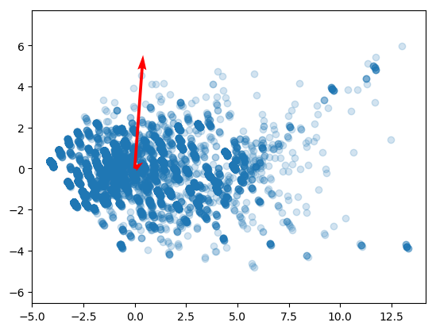

```python
X2D = model.transform(X)

plt.scatter(X2D[:, 0], X2D[:, 1], alpha=0.2)
for length, vector in zip(model.explained_variance_, model.components_):
    v = vector * 3 * np.sqrt(length)
    plt.quiver( np.mean(model.mean_), np.mean(model.mean_ + v), color=['r'], scale=7)
plt.axis('equal')
plt.show();
```

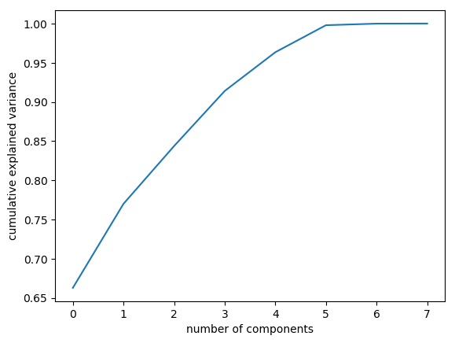

```python
pca = PCA().fit(X)
plt.plot(np.cumsum(pca.explained_variance_ratio_))
plt.xlabel('number of components')
plt.ylabel('cumulative explained variance');
plt.show()
```

###### Choosing the number of components

In PCA is crucial to getting a estimate on how many components are needed to explain the data. Witht he explain variance ratio as a function with respect to the number of components we can se the amount of components needed to accuatly describe the data.

#### Running classifiers on PCA transformed data

For this experiment in the PCA analysis we will use our best classifiers to see if PCA can improve the prediction. Our best classifiers include gradient boosting and a voting classifier.

```python
X_dim2 = model.transform(X)
X_train_PCA, X_test_PCA, y_train_PCA, y_test_PCA = train_test_split(X_dim2, y, test_size=.30)
learning_rates = np.arange(0.25,1.5,0.25)
gradBoost(X_train_PCA, y_train_PCA, X_test_PCA, y_test_PCA,learning_rates)
```

```
Learning rate:  0.25
Accuracy score for training data : 0.808
Accuracy score for TEST set: 0.811
Learning rate:  0.5
Accuracy score for training data : 0.817
Accuracy score for TEST set: 0.816
Learning rate:  0.75
Accuracy score for training data : 0.820
Accuracy score for TEST set: 0.817
Learning rate:  1.0
Accuracy score for training data : 0.820
Accuracy score for TEST set: 0.812
Learning rate:  1.25
Accuracy score for training data : 0.819
Accuracy score for TEST set: 0.814
```

```python
votingClass(X_train_PCA, y_train_PCA, X_test_PCA, y_test_PCA)
```

```
ExtraTreesClassifier 0.75
LogisticRegression 0.8021333333333334
RandomForestClassifier 0.7590666666666667
SVC 0.8166666666666667
VotingClassifier 0.8118666666666666
```

As we can see the best classifier for PCA is roughly either gradient boosting with a learning rate of .5 or our SVC inside the voting classifier getting values ranging roughly from .81% to .825%. Also these results are very similar to the original data being tested on gradient boost and the voting classifier which means that the PCA was sucessful in determining the amount of components required to describe the data.

#### Incremental PCA

One problem with the preceding implementation of PCA is that it requires the whole training set to fit in memory. Incremental PCA (IPCA) can split the training set into mini-batches and is useful for large training sets, and also to apply PCA online. However the dataset is small enough that this is not required.

```python
n_batches = 100
inc_pca = IncrementalPCA(n_components= 2)
X_copy = X
X_iPCA = model.fit_transform(X_copy)
for X_batch in np.array_split(X_copy, n_batches):
    inc_pca.partial_fit(X_batch)
    X_iPCA = inc_pca.transform(X_copy)
print(X_iPCA.shape)

X_train_iPCA, X_test_iPCA, y_train_iPCA, y_test_iPCA = train_test_split(X_iPCA, y, test_size=.30)

gradBoost(X_train_iPCA, y_train_iPCA, X_test_iPCA, y_test_iPCA,learning_rates)
```

```
(25000, 2)
Learning rate:  0.25
Accuracy score for training data : 0.814
Accuracy score for TEST set: 0.813
Learning rate:  0.5
Accuracy score for training data : 0.818
Accuracy score for TEST set: 0.816
Learning rate:  0.75
Accuracy score for training data : 0.818
Accuracy score for TEST set: 0.817
Learning rate:  1.0
Accuracy score for training data : 0.821
Accuracy score for TEST set: 0.815
Learning rate:  1.25
Accuracy score for training data : 0.818
Accuracy score for TEST set: 0.813
```

```python
votingClass(X_train_iPCA, y_train_iPCA, X_test_iPCA, y_test_iPCA)
```

```
ExtraTreesClassifier 0.7604
LogisticRegression 0.8114666666666667
RandomForestClassifier 0.7701333333333333
SVC 0.8157333333333333
VotingClassifier 0.8153333333333334
```

#### Randomized PCA

Another option for larger datasets is to perform Randomized PCA, this is a stochastic algorithm which takes a quick equivalence of the first principal component. This algorithm is faster than Incremental PCA and PCA in general as long as d is smaller than that of n where the complexity is O(m × d2) + O(d3), instead of O(m × n2) + O(n3).

```python
rnd_pca = PCA(n_components=5, svd_solver="randomized")
X_rPCA = rnd_pca.fit_transform(X_copy)

X_train_rPCA, X_test_rPCA, y_train_rPCA, y_test_rPCA = train_test_split(X_rPCA, y, test_size=.30)

gradBoost(X_train_rPCA, y_train_rPCA, X_test_rPCA, y_test_rPCA,learning_rates)
```

```
Learning rate:  0.25
Accuracy score for training data : 0.817
Accuracy score for TEST set: 0.823
Learning rate:  0.5
Accuracy score for training data : 0.817
Accuracy score for TEST set: 0.823
Learning rate:  0.75
Accuracy score for training data : 0.819
Accuracy score for TEST set: 0.817
Learning rate:  1.0
Accuracy score for training data : 0.818
Accuracy score for TEST set: 0.819
Learning rate:  1.25
Accuracy score for training data : 0.817
Accuracy score for TEST set: 0.814
```

```python
votingClass(X_train_rPCA, y_train_rPCA, X_test_rPCA, y_test_rPCA)
```

```
ExtraTreesClassifier 0.7586666666666667
LogisticRegression 0.8144
RandomForestClassifier 0.7648
SVC 0.8218666666666666
VotingClassifier 0.8204
```

# Ensemble Learning Methods & Hyperparameter Tuning

## Voting Classifier

```python
def votingClass(X_train,y_train,X_test,y_test):
    extra_trees_clf = ExtraTreesClassifier(random_state=42)
    mlp_clf = MLPClassifier(random_state=42)
    log_clf = LogisticRegression(random_state=42)
    rnd_clf = RandomForestClassifier(random_state=42)
    svm_clf = SVC(random_state=42)
    voting_clf = VotingClassifier(
        estimators=[('xt', extra_trees_clf), ('mlp', mlp_clf), ('lr', log_clf), ('rf', rnd_clf), ('svc', svm_clf)],
        voting='hard')
    voting_clf.fit(X_train, y_train)
    from sklearn.metrics import accuracy_score
    for clf in (extra_trees_clf, log_clf, rnd_clf, svm_clf, voting_clf):
        clf.fit(X_train, y_train)
        y_pred = clf.predict(X_test)
        print(clf.__class__.__name__, accuracy_score(y_test, y_pred))
```

```python
#Soft voting classifier
votingClass(X_train,y_train,X_test,y_test)
```

```
ExtraTreesClassifier 0.7737333333333334
LogisticRegression 0.8124
RandomForestClassifier 0.7882666666666667
SVC 0.8273333333333334
VotingClassifier 0.8230666666666666
```

### Hard voting

```python
def votingClassHard(X_train,y_train,X_test,y_test):
    extra_trees_clf = ExtraTreesClassifier(random_state=42)
    log_clf = LogisticRegression(random_state=42)
    rnd_clf = RandomForestClassifier(random_state=42)
    svm_clf = SVC(random_state=42)
    voting_clf = VotingClassifier(
        estimators=[('xt', extra_trees_clf), ('lr', log_clf), ('rf', rnd_clf), ('svc', svm_clf)],
        voting='hard')
    voting_clf.fit(X_train, y_train)
    from sklearn.metrics import accuracy_score
    for clf in (extra_trees_clf, log_clf, rnd_clf, svm_clf, voting_clf):
        clf.fit(X_train, y_train)
        y_pred = clf.predict(X_test)
        print(clf.__class__.__name__, accuracy_score(y_test, y_pred))
```

```python
#Hard voting classifier
votingClassHard(X_train,y_train,X_test,y_test)
```

```
ExtraTreesClassifier 0.7737333333333334
LogisticRegression 0.8124
RandomForestClassifier 0.7882666666666667
SVC 0.8273333333333334
VotingClassifier 0.8177333333333333
```

## Gradient Boosting

Our first ensemble method that we're going to use is Gradient Boosting. We are gonna be tuning hyperparameters trying to get a better accuracy.

Here I decide to use various learning rates to use for tuning the hyperparameters.

```python
rates = [1e-3,0.05, 0.1, 0.25, 0.5, 0.75, 1, 1.5]
```

Here I tune the hyperparameter learning rate by looping through diferrent learning rates and seeing which ones results in a better accuracy. Than I'll use the best learning rate for the model to get the best accuracy for the model.

```python
def gradBoost(X_train,y_train,X_test,y_test,learning_rates):
    # learning_rates = np.arange(0.74,.76,0.001)
    for learning_rate in learning_rates:
        boost = GradientBoostingClassifier(n_estimators=20, learning_rate = learning_rate, max_features=2, max_depth = 2, random_state = 0)
        boost.fit(X_train, y_train)
        print("Learning rate: ", learning_rate)
        print("Accuracy score for training data : {0:.3f}".format(boost.score(X_train, y_train)))
        print("Accuracy score for test set: {0:.3f}".format(boost.score(X_test, y_test)))
```

We print the accuracy of the Gradient Boosting Classifier via the training and testing data based on the different learning rates.

```python
gradBoost(X_train,y_train,X_test,y_test,rates)
```

```
Learning rate:  0.001
Accuracy score for training data : 0.777
Accuracy score for test set: 0.784
Learning rate:  0.05
Accuracy score for training data : 0.793
Accuracy score for test set: 0.803
Learning rate:  0.1
Accuracy score for training data : 0.807
Accuracy score for test set: 0.819
Learning rate:  0.25
Accuracy score for training data : 0.810
Accuracy score for test set: 0.818
Learning rate:  0.5
Accuracy score for training data : 0.814
Accuracy score for test set: 0.820
Learning rate:  0.75
Accuracy score for training data : 0.815
Accuracy score for test set: 0.820
Learning rate:  1
Accuracy score for training data : 0.815
Accuracy score for test set: 0.821
Learning rate:  1.5
Accuracy score for training data : 0.805
Accuracy score for test set: 0.816
```

## Bagging

This experiment with bagging uses 500 decision tree classifiers trained with 100 randomly sampled instances.

```python
bag_clf = BaggingClassifier(
    DecisionTreeClassifier(random_state=42), n_estimators=500,
    max_samples=100, bootstrap=True, n_jobs=-1, random_state=42)
bag_clf.fit(X_train, y_train)
y_pred = bag_clf.predict(X_test)


from sklearn.metrics import accuracy_score
print(accuracy_score(y_test, y_pred))
```

```
0.8270666666666666
```

We are still hovering at the 82% prediction accuracy with this model.